# **PRA 2 Limpieza y Validación de los Datos**

Diego Armando Quintero (diegoquintero424) – Adrian Felipe Pinzon Hurtado (apinzonh)

Fecha: Enero 2022

# 1 **Descripción del Dataset**

## 1.1 Presentación y problemática (desafío)

(tomado de https://www.kaggle.com/c/titanic) El hundimiento del Titanic es uno de los naufragios más infames de la historia.

El 15 de abril de 1912, durante su viaje inaugural, el RMS Titanic, ampliamente considerado “insumergible”, se hundió después de chocar con un iceberg. Desafortunadamente, no había suficientes botes salvavidas para todos a bordo, lo que resultó en la muerte de 1502 de los 2224 pasajeros y la tripulación.

Si bien hubo algún elemento de suerte involucrado en sobrevivir, parece que algunos grupos de personas tenían más probabilidades de sobrevivir que otros.

En este desafío, le pedimos que cree un modelo predictivo que responda a la pregunta: “¿Qué tipo de personas tenían más probabilidades de sobrevivir?” utilizando datos de pasajeros (es decir, nombre, edad, sexo, clase socioeconómica, etc.).

## 1.2 Exploración de dataset, variables y extracción visual de información

Carga de los datos - Tres archivos:

Obtenemos que disponemos de:

TABLA RESUMEN ARCHIVOS

| Datas | Registros | Variables |
| --- | --- | --- |
| Test | 418 | 11 variables (columnas) |
| Train | 891 | 12 variables (columnas) |
| gender_submission | 418 | 2 variables (columnas) |

* Realizado con funciones dim() y str()

TABLA RESUMEN VARIABLES DATA ‘TEST’

| Variable | Descripcion |
| --- | --- |
| PassengerId | (tipo entero) Identificación del pasajero. Ej.: 892, 893. Variable continua |
| Pclass | (tipo entero) Clase del pasajero. Ej.: 3,2. Variable Discreta |
| Name | (tipo factor) 418 niveles. Nombre del pasajero. Ej.: ‘Abbott, Master. Eugene Joseph’ |
| Sex | (tipo factor) 2 niveles. Sexo del pasajero. Ej.: female, male. Variable categoríca |
| Age | (tipo número). Edad del pasajero. Ej.: 34, 47 Variable discreta |
| SibSp | (tipo entero). Ej.: 0,1 Variable Discreta |
| Parch | (tipo entero). Ej.: 0,1 Variable discreta |
| Ticket | (tipo factor) 363 niveles. Tiquetes. Ej.: 110469, 110489. Variable categoríca |
| Fare | (tipo número) Tarifas. Ej.: 7.83, 9.69 Variable continua |
| Cabin | (tipo factor) 77 niveles Cabina en la que estaba el pasajero. Ej.: A11, A18 Variable categoríca |
| Embarked | (tipo factor) 3 niveles. Tipo de emarque del pasajero. Ej.: C, Q Variable categoríca. |

* Esta es la salida del código hecho con read.table

TABLA RESUMEN VARIABLES DATA ‘TRAIN’

| Variable | Descripcion |
| --- | --- |
| PassengerId | (tipo entero) Identificación del pasajero. Ej.: 1, 2, 3…Variable continua |
| Survived | (tipo entero) Si sobrevivió o no. Ej.: 0, 1. Variable dicotómica discreta |
| Pclass | (tipo entero) Clase del pasajero. Ej.: 1, 3,2. Variable Discreta |
| Name | (tipo factor) 891 niveles. Nombre del pasajero. Ej.: ‘Abbing, Mr. Anthony’ Variable categoríca |
| Sex | (tipo factor) 2 niveles. Sexo del pasajero. Ej.: female, male. Variable categórica |
| Age | (tipo número). Edad del pasajero. Ej.: 34, 47, NA. Variable Discreta |
| SibSp | (tipo entero). Ej.: 0,1,2. Variable Discreta |
| Parch | (tipo entero). Ej.: 0,1,2. Variable Discreta |
| Ticket | (tipo factor) 681 niveles. Tiquetes. Ej.:‘110152’,‘110413’,..:.524, 597 Variable categórica |
| Fare | (tipo número) Tarifas. Ej.: 7.25, 71.28. Variable continua |
| Cabin | (tipo factor) 148 niveles Cabina en la que estaba el pasajero. Ej.: ‘A10’, ‘A14’: ..: 1 83…Variable categoríca |
| Embarked | (tipo factor) 4 niveles. Tipo de emarque del pasajero. Ej.: ‘C’,‘Q’,‘S’: 4 2 4 4… Variable categoríca |

* Esta es la salida del código hecho con read.table

TABLA RESUMEN VARIABLES DATA ‘GENDER_SUBMISSION’

| Variable | Descripcion |
| --- | --- |
| PassengerId | (tipo entero) Identificación del pasajero. Ej.: 1, 2, 3…Variable continua |
| Survived | (tipo entero) Si sobrevivió o no. Ej.: 0, 1… Variable dicotómica discreta. |

* Esta es la salida del código hecho con read.table

# 2 **Integración y selección de los datos de interés a analizar**

Se decide juntar la base de datos de train y de test en una sola.

Lo primero paso es que la data Test tenga las mismas doce variables de Train, como falta el dato de Survived, se debe realizar un join por la variable PassangerId entre Test y gender_submission, para obtener los valores de este campo Survived:

```r
test_12<-merge(x=data,y=data2,by="PassengerId",all.x=TRUE)

#head(test_12)
```

Luego se junta las datas de test y train:

```r
dfj <- c()
dfj <-rbind(test_12,data1)
#head(dfj)
```

Finalmente, se muestra la información de la data unificada:

```r
summary(dfj)
```

```
##   PassengerId       Pclass          Name               Sex
##  Min.   :   1   Min.   :1.000   Length:1309        Length:1309
##  1st Qu.: 328   1st Qu.:2.000   Class :character   Class :character
##  Median : 655   Median :3.000   Mode  :character   Mode  :character
##  Mean   : 655   Mean   :2.295
##  3rd Qu.: 982   3rd Qu.:3.000
##  Max.   :1309   Max.   :3.000
##
##       Age            SibSp            Parch          Ticket
##  Min.   : 0.17   Min.   :0.0000   Min.   :0.000   Length:1309
##  1st Qu.:21.00   1st Qu.:0.0000   1st Qu.:0.000   Class :character
##  Median :28.00   Median :0.0000   Median :0.000   Mode  :character
##  Mean   :29.88   Mean   :0.4989   Mean   :0.385
##  3rd Qu.:39.00   3rd Qu.:1.0000   3rd Qu.:0.000
##  Max.   :80.00   Max.   :8.0000   Max.   :9.000
##  NA's   :263
##       Fare            Cabin             Embarked            Survived
##  Min.   :  0.000   Length:1309        Length:1309        Min.   :0.0000
##  1st Qu.:  7.896   Class :character   Class :character   1st Qu.:0.0000
##  Median : 14.454   Mode  :character   Mode  :character   Median :0.0000
##  Mean   : 33.295                                         Mean   :0.3774
##  3rd Qu.: 31.275                                         3rd Qu.:1.0000
##  Max.   :512.329                                         Max.   :1.0000
##  NA's   :1
```

# 3 **Limpieza de los datos**

## 3.1 ¿Los datos contienen ceros o elementos vacíos?

Gracias a la función summary se responde:  
Sí, la data unificada tiene 263 datos nulos en “Age” y uno en “Fare”. (campos vacíos).  
Para el tratamiento de estos NAs, se realizará la imputación con al algoritmo Gower - KNN.

MUESTRA DE REGISTROS IMPUTADOS POR MEDIDA GOWER PARA AGE

|  | PassengerId | Pclass | Name | Sex | Age | SibSp | Parch | Ticket | Fare | Cabin | Embarked | Survived | Age_Imputada | Fare_Imputada |
| --- | --- | --- | --- | --- | --- | --- | --- | --- | --- | --- | --- | --- | --- | --- |
| 11 | 902 | 3 | Ilieff, Mr. Ylio | male | 25 | 0 | 0 | 349220 | 7.8958 |  | S | 0 | TRUE | FALSE |
| 23 | 914 | 1 | Flegenheim, Mrs. Alfred (Antoinette) | female | 24 | 0 | 0 | PC 17598 | 31.6833 |  | S | 1 | TRUE | FALSE |
| 30 | 921 | 3 | Samaan, Mr. Elias | male | 6 | 2 | 0 | 2662 | 21.6792 |  | C | 0 | TRUE | FALSE |
| 34 | 925 | 3 | Johnston, Mrs. Andrew G (Elizabeth Lily” Watson)” | female | 20 | 1 | 2 | W./C. 6607 | 23.4500 |  | S | 1 | TRUE | FALSE |
| 37 | 928 | 3 | Roth, Miss. Sarah A | female | 24 | 0 | 0 | 342712 | 8.0500 |  | S | 1 | TRUE | FALSE |

* Se observa si esa fila tuvo variable imputada en columna roja

MUESTRA DE REGISTROS IMPUTADOS POR MEDIDA GOWER PARA FARE

|  | PassengerId | Pclass | Name | Sex | Age | SibSp | Parch | Ticket | Fare | Cabin | Embarked | Survived | Age_Imputada | Fare_Imputada |
| --- | --- | --- | --- | --- | --- | --- | --- | --- | --- | --- | --- | --- | --- | --- |
| 153 | 1044 | 3 | Storey, Mr. Thomas | male | 60.5 | 0 | 0 | 3701 | 76.2917 |  | S | 0 | FALSE | TRUE |

* Se observa si esa fila tuvo variable imputada en columna roja

```r
#eliminar columnas del dataframe:
df <- c()
df <- dfNA[, -c(13:14)]
#head(df)
str(df)
```

```
## 'data.frame':    1309 obs. of  12 variables:
##  $ PassengerId: int  892 893 894 895 896 897 898 899 900 901 ...
##  $ Pclass     : int  3 3 2 3 3 3 3 2 3 3 ...
##  $ Name       : chr  "Kelly, Mr. James" "Wilkes, Mrs. James (Ellen Needs)" "Myles, Mr. Thomas Francis" "Wirz, Mr. Albert" ...
##  $ Sex        : chr  "male" "female" "male" "male" ...
##  $ Age        : num  34.5 47 62 27 22 14 30 26 18 21 ...
##  $ SibSp      : int  0 1 0 0 1 0 0 1 0 2 ...
##  $ Parch      : int  0 0 0 0 1 0 0 1 0 0 ...
##  $ Ticket     : chr  "330911" "363272" "240276" "315154" ...
##  $ Fare       : num  7.83 7 9.69 8.66 12.29 ...
##  $ Cabin      : chr  "" "" "" "" ...
##  $ Embarked   : chr  "Q" "S" "Q" "S" ...
##  $ Survived   : int  0 1 0 0 1 0 1 0 1 0 ...
```

```r
dim(df)
```

```
## [1] 1309   12
```

**Limpiezas iniciales**  
Se pasa las variables Pclass y Survived a factor.  
Se observa la variable Cabin con números y letras y en algunos casos, un registro hasta con 5 cabinas. Se decide con regex (análisis de texto), dividir esta variable en 2: Cabin_Letra y Cabin_Numero, pues puede dar un análisis interesante más adelante.  
Después de la revisión se encuentran 1020 casos NAs. Se decide no tomar esta variable para estudio.

TABLA MUESTRA CON NUEVAS VARIABLES Cabin Numero y Letra

| PassengerId | Pclass | Name | Sex | Age | SibSp | Parch | Ticket | Fare | Cabin | Embarked | Survived | Cabin_Letra | Cabin_Numero |
| --- | --- | --- | --- | --- | --- | --- | --- | --- | --- | --- | --- | --- | --- |
| 892 | 3 | Kelly, Mr. James | male | 34.5 | 0 | 0 | 330911 | 7.8292 |  | Q | 0 | NA | NA |
| 893 | 3 | Wilkes, Mrs. James (Ellen Needs) | female | 47.0 | 1 | 0 | 363272 | 7.0000 |  | S | 1 | NA | NA |

* Se observan en rojo que los valores tomados fueron NAs.

```
##   PassengerId       Pclass          Name               Sex
##  Min.   :   1   Min.   :1.000   Length:1309        Length:1309
##  1st Qu.: 328   1st Qu.:2.000   Class :character   Class :character
##  Median : 655   Median :3.000   Mode  :character   Mode  :character
##  Mean   : 655   Mean   :2.295
##  3rd Qu.: 982   3rd Qu.:3.000
##  Max.   :1309   Max.   :3.000
##
##       Age            SibSp            Parch          Ticket
##  Min.   : 0.17   Min.   :0.0000   Min.   :0.000   Length:1309
##  1st Qu.:22.00   1st Qu.:0.0000   1st Qu.:0.000   Class :character
##  Median :27.00   Median :0.0000   Median :0.000   Mode  :character
##  Mean   :29.42   Mean   :0.4989   Mean   :0.385
##  3rd Qu.:36.00   3rd Qu.:1.0000   3rd Qu.:0.000
##  Max.   :80.00   Max.   :8.0000   Max.   :9.000
##
##       Fare            Cabin             Embarked            Survived
##  Min.   :  0.000   Length:1309        Length:1309        Min.   :0.0000
##  1st Qu.:  7.896   Class :character   Class :character   1st Qu.:0.0000
##  Median : 14.454   Mode  :character   Mode  :character   Median :0.0000
##  Mean   : 33.328                                         Mean   :0.3774
##  3rd Qu.: 31.275                                         3rd Qu.:1.0000
##  Max.   :512.329                                         Max.   :1.0000
##
##  Cabin_Letra         Cabin_Numero
##  Length:1309        Min.   :1.000
##  Class :character   1st Qu.:2.000
##  Mode  :character   Median :3.000
##                     Mean   :3.972
##                     3rd Qu.:6.000
##                     Max.   :9.000
##                     NA's   :1020
```

## 3.2 Análisis de los datos

**Resumen de datos cuantitativos**  
En el análisis inicial, no se incluye Ticket ni Cabin por demasiados NAs:

```r
res <- c("Age","SibSp","Parch","Fare" )
mean.n <- as.vector(sapply( df[,res ],mean,na.rm=TRUE ) )
std.n <- as.vector(sapply(df[,res ],sd, na.rm=TRUE))
median.n <- as.vector(sapply(df[,res],median, na.rm=TRUE))
IQR.n <- as.vector(sapply(df[,res],IQR, na.rm=TRUE))
```

```r
#head(df)
```

```r
id.factor <- c(12)
id.num <- c(5,6,7,9)
var.factor <- colnames(df)[id.factor]
var.num <- colnames(df)[id.num]

variables_continuas <-  c()
variables_continuas <-data.frame(df)

resumen_vc <- function(x){
                m <- round(mean(x),2)
                me <- round(median(x),2)
                q <- round(quantile(x),2)
                n <- length(x)
                s <- round(sd(x),2)
                cv <- round(sd(x)/mean(x),2)
                IQR <- IQR(x)
                return(c(TOTAL=n, Media=m, Mediana=me, Cuartiles=q,Intercuartilico=IQR,S=s, CV=cv))
}

VC <- c("Age","SibSp", "Parch", "Fare")

tabla_vc_ve <- sapply(variables_continuas[VC], resumen_vc)

kable(tabla_vc_ve,caption = "TABLA RESUMEN VARIABLES CUANTITATIVAS REFERENTE A SURVIVED") %>%
  kable_styling(fixed_thead = T)%>%
  column_spec(1, bold = T, color = "gray", background = "#EAF5F9") %>%
  column_spec(2, bold = T, color = "gray", background = "#DAF5FD") %>%
  column_spec(3, bold = T, color = "gray", background = "#CAF2FF") %>%
  column_spec(4, bold = T, color = "gray", background = "#A1E9FF") %>%
   column_spec(5, bold = T, color = "gray", background = "#18D6F3") %>%
    add_footnote(c("Convenciones: S:Varianza, CV:Desviación Estandar"), notation = "symbol")
```

TABLA RESUMEN VARIABLES CUANTITATIVAS REFERENTE A SURVIVED

|  | Age | SibSp | Parch | Fare |
| --- | --- | --- | --- | --- |
| TOTAL | 1309.00 | 1309.00 | 1309.00 | 1309.0000 |
| Media | 29.42 | 0.50 | 0.39 | 33.3300 |
| Mediana | 27.00 | 0.00 | 0.00 | 14.4500 |
| Cuartiles.0% | 0.17 | 0.00 | 0.00 | 0.0000 |
| Cuartiles.25% | 22.00 | 0.00 | 0.00 | 7.9000 |
| Cuartiles.50% | 27.00 | 0.00 | 0.00 | 14.4500 |
| Cuartiles.75% | 36.00 | 1.00 | 0.00 | 31.2700 |
| Cuartiles.100% | 80.00 | 8.00 | 9.00 | 512.3300 |
| Intercuartilico | 14.00 | 1.00 | 0.00 | 23.3792 |
| S | 13.40 | 1.04 | 0.87 | 51.7500 |
| CV | 0.46 | 2.09 | 2.25 | 1.5500 |

El rango intercualtílico es Q3-Q1. Como entre Q3 y Q4 se distribuyen más del 50% de las observaciones centrales de las variables (excepto Age), el rango intercuartilico es una medida de la dispersión de este colectivo. Así pues, indica no normalidad.  
La variable Age tiene una buena distribución entre los cuartiles y su CV la hace atractiva para el modelo.

Se analiza la correlación entre estas variables:

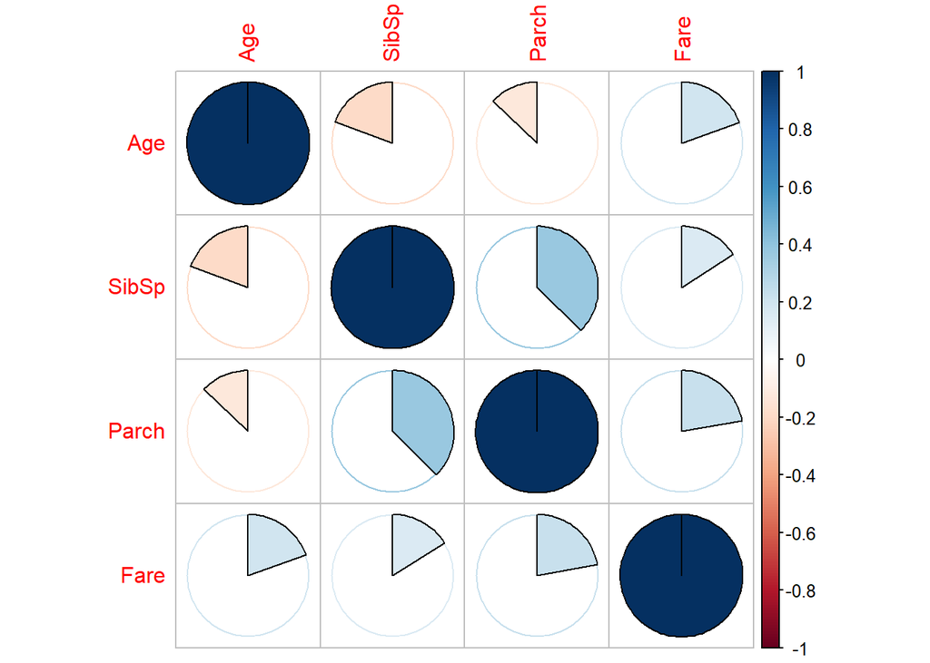

```r
#VC <- c("SibSp", "Parch", "Fare")
M<-cor(variables_continuas[VC])

corrplot(M, method="pie")
```

## 3.3 Identificación y tratamiento de valores extremos

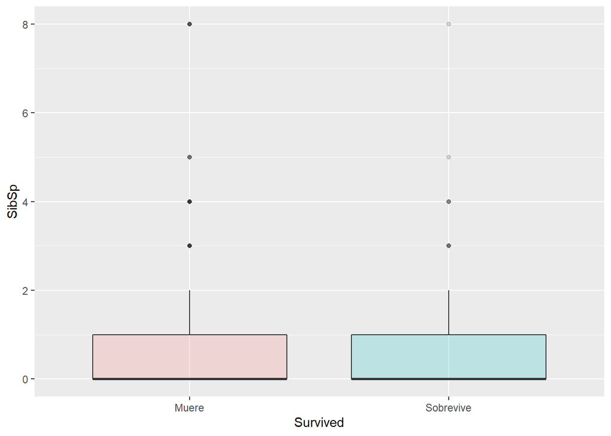

```r
SURVIVED <- c("Muere","Sobrevive")
df$Survived <- factor(df$Survived, levels = c(0,1), labels=SURVIVED)

ggplot(df, aes(x=Survived, y=SibSp, fill=Survived)) +
    geom_boxplot(alpha=0.2) +
    theme(legend.position="none")
```

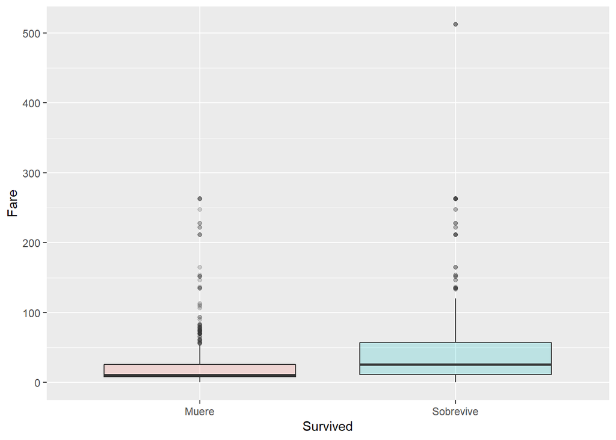

```r
ggplot(df, aes(x=Survived, y=Fare, fill=Survived)) +
    geom_boxplot(alpha=0.2) +
    theme(legend.position="none")
```

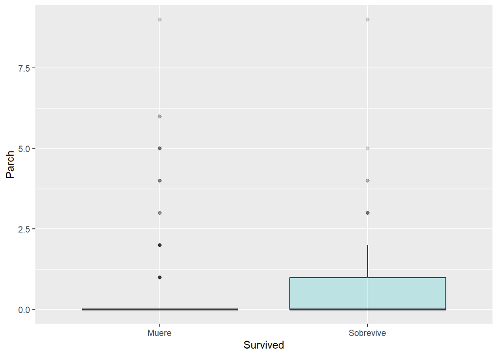

```r
ggplot(df, aes(x=Survived, y=Parch, fill=Survived)) +
    geom_boxplot(alpha=0.2) +
    theme(legend.position="none")
```

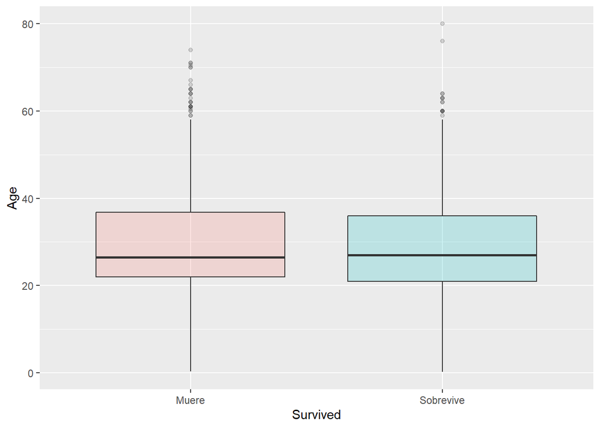

```r
ggplot(df, aes(x=Survived, y=Age, fill=Survived)) +
    geom_boxplot(alpha=0.2) +
    theme(legend.position="none")
```

**Discretización**

Se crea nueva variable de Tipo_Persona (niño, adulto, mayor) a partir de la variable Age.

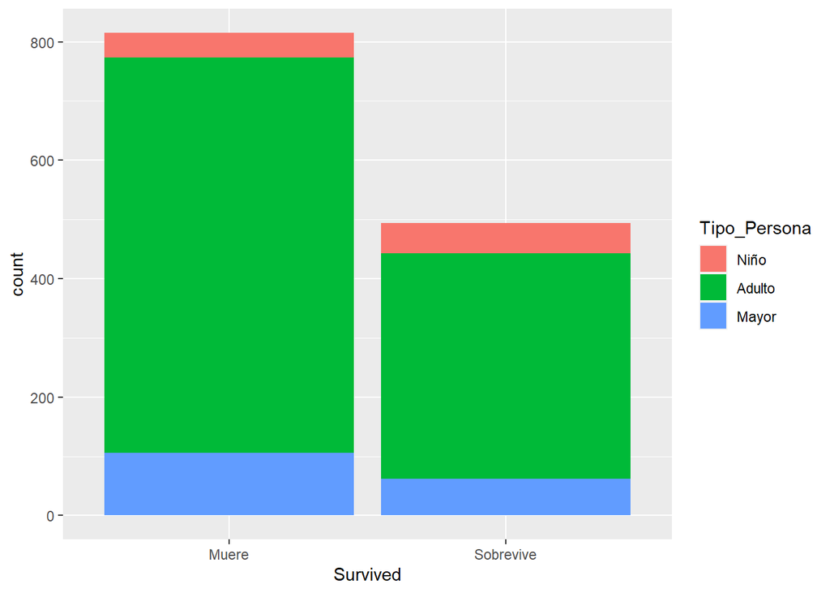

```r
# Discretizamos
df["Tipo_Persona"] <- cut(df$Age, breaks = c(0,10,45,100), labels = c("Niño","Adulto","Mayor"))

#df["Clase"] <- cut(df$Pclass, breaks = c(0,1,2,3), labels = c("1ra", "2da", "3ra"))
#df <- subset(df, select = -c(Pclass) )
clase <- c("1ra", "2da", "3ra")
df$Pclass <- factor(df$Pclass, levels = c(1,2,3), labels=clase)




filas1=dim(df)[1]
ggplot(data=df[1:filas1,],aes(x=Survived,fill=Tipo_Persona))+geom_bar()
```

## 3.4 Comparación de la normalidad y homogeneidad de la varianza

R:/ Se calcula para Age:

Invertalo de confianza de la variable Age

Se realizará cálculo del intervalo de confianza al 95% de la variable Age.

La prueba de homogeneidad es una prueba estadística inferencial utilizada para evaluar la igualdad de las varianzas para una variable calculada para dos o más grupos, algunas de las formas más utilizadas es analizarlo de forma gráfica, Dos de los métodos gráficos más empleados para el análisis homogeneidad consiste en representar los datos mediante un boxplot o un violinplot. Con ambos gráficos el objetivo es comparar la dispersión de los grupos.

A continuación se realiza el análisis con la variable Survived y la edad

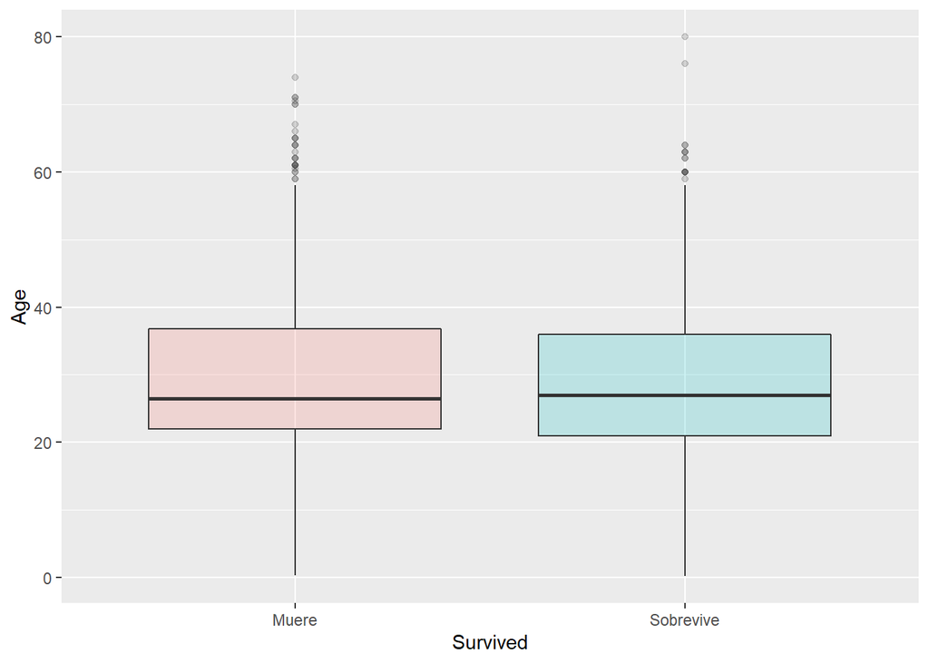

```r
ggplot(df, aes(x=Survived, y=Age, fill=Survived)) +
    geom_boxplot(alpha=0.2) +
    theme(legend.position="none")
```

Del gráfico se puede concluir de que tienen una forma similar y por lo tanto se presenta homogeneidad entre los datos.

```r
alpha<-0.05
n<-length(df$Age)
n
```

```
## [1] 1309
```

```r
#Aplicamos el teorema del límite central ya que la muestra es superior a 30
mean <- mean(df$Age)
s <- sd(df$Age)
t <- qnorm(alpha/2, lower.tail= FALSE) # normal
#t<-qt(alpha/2,lower.tail=FALSE,df=n-1) # t-student
li <- mean - t*s/ sqrt(n)
ui <- mean + t*s/ sqrt(n)

cat( "(" , li , ",", ui , ")")
```

```
## ( 28.6912 , 30.14328 )
```

```r
tt<-t.test(df$Age, conf.level=0.95 )
tt
```

```
##
##  One Sample t-test
##
## data:  df$Age
## t = 79.413, df = 1308, p-value < 2.2e-16
## alternative hypothesis: true mean is not equal to 0
## 95 percent confidence interval:
##  28.69053 30.14395
## sample estimates:
## mean of x
##  29.41724
```

```r
tt$conf.int
```

```
## [1] 28.69053 30.14395
## attr(,"conf.level")
## [1] 0.95
```

```r
#attr(,"conf.level")
```

El intervalo de confianza que obtenemos es: (28.69,30.14). La media muestral es 29.41 y el p-value 2.2*10^-16. La interpretación del intervalo de confianza es que si muestreamos un número elevado de veces la población, el 95 % de los intervalos obtenidos contienen el valor del parámetro de la media de Age.

**Resumen Variables cualitativas**  
Se realiza relación con base en la variable Survived:

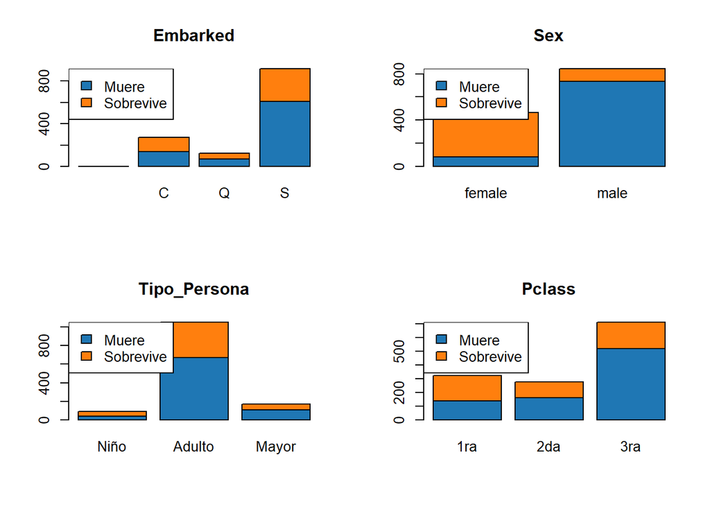

```r
par(mfrow=c(2,2))

factorColumns <- c("Embarked", "Sex","Tipo_Persona","Pclass")



for (col in factorColumns) {
  table <- table(df$Survived, df[[col]])
    barplot(table,
            col=c("#1F77B4", "#FF7F0E"),
            main = col)

legend("topleft", SURVIVED, fill=c("#1F77B4","#FF7F0E"))
}
```

# 4 **Análisis de los datos**

## 4.1 Selección de los grupos de datos que se quieren analizar/comparar (planificación de los análisis a aplicar)

Las embarcaciones en S fueron mayoría y esta murieron más de 400 personas.  
Se encontraron más hombres que mujeres viajando, pero murieron más hombres que mujeres.  
Habían más personas adultas que niños o mayores(ancianos), y estos adultos fueron los que más muertos pusieron en la catástrofe.  
Se encontraban más de 3ra clase en el Titanic, y fueron los que más murieron.

```r
tabla_SET <- table(df$Embarked,df$Survived)
kable(prop.table(tabla_SET, margin = 1),caption = "TABLA CONTINGENCIA EMBARKED VS SURVIVED") %>%
  kable_styling(fixed_thead = T)%>%
  column_spec(1, bold = T, color = "gray", background = "#EAF5F9") %>%
  column_spec(2, bold = T, color = "gray", background = "#DAF5FD") %>%
  column_spec(3, bold = T, color = "gray", background = "#CAF2FF") %>%
     add_footnote(c(""), notation = "symbol")
```

TABLA CONTINGENCIA EMBARKED VS SURVIVED

|  | Muere | Sobrevive |
| --- | --- | --- |
|  | 0.0000000 | 1.0000000 |
| C | 0.5074074 | 0.4925926 |
| Q | 0.5609756 | 0.4390244 |
| S | 0.6663020 | 0.3336980 |

```r
tabla_SST <- table(df$Sex, df$Survived)
kable(prop.table(tabla_SST, margin = 1),caption = "TABLA CONTINGENCIA SEX VS SURVIVED") %>%
  kable_styling(fixed_thead = T)%>%
  column_spec(1, bold = T, color = "gray", background = "#EAF5F9") %>%
  column_spec(2, bold = T, color = "gray", background = "#DAF5FD") %>%
  column_spec(3, bold = T, color = "gray", background = "#CAF2FF") %>%
     add_footnote(c(""), notation = "symbol")
```

TABLA CONTINGENCIA SEX VS SURVIVED

|  | Muere | Sobrevive |
| --- | --- | --- |
| female | 0.1738197 | 0.8261803 |
| male | 0.8706999 | 0.1293001 |

```r
tabla_SCT <- table(df$Pclass,df$Survived)
kable(prop.table(tabla_SCT, margin = 1),caption = "TABLA CONTINGENCIA CLASS VS SURVIVED") %>%
  kable_styling(fixed_thead = T)%>%
  column_spec(1, bold = T, color = "gray", background = "#EAF5F9") %>%
  column_spec(2, bold = T, color = "gray", background = "#DAF5FD") %>%
  column_spec(3, bold = T, color = "gray", background = "#CAF2FF") %>%
    add_footnote(c(""), notation = "symbol")
```

TABLA CONTINGENCIA CLASS VS SURVIVED

|  | Muere | Sobrevive |
| --- | --- | --- |
| 1ra | 0.4241486 | 0.5758514 |
| 2da | 0.5776173 | 0.4223827 |
| 3ra | 0.7306065 | 0.2693935 |

```r
tabla_SAT <- table(df$Tipo_Persona,df$Survived)
kable(prop.table(tabla_SAT, margin = 1),caption = "TABLA CONTINGENCIA TIPO_PERSONA VS SURVIVED") %>%
  kable_styling(fixed_thead = T)%>%
  column_spec(1, bold = T, color = "gray", background = "#EAF5F9") %>%
  column_spec(2, bold = T, color = "gray", background = "#DAF5FD") %>%
  column_spec(3, bold = T, color = "gray", background = "#CAF2FF") %>%
    add_footnote(c(""), notation = "symbol")
```

TABLA CONTINGENCIA TIPO_PERSONA VS SURVIVED

|  | Muere | Sobrevive |
| --- | --- | --- |
| Niño | 0.4516129 | 0.5483871 |
| Adulto | 0.6364504 | 0.3635496 |
| Mayor | 0.6309524 | 0.3690476 |

Una alternativa interesante a las barras de diagramas, es el plot de las tablas de contingencia. Obtenemos la misma información pero para algunos receptores puede resultar más visual.

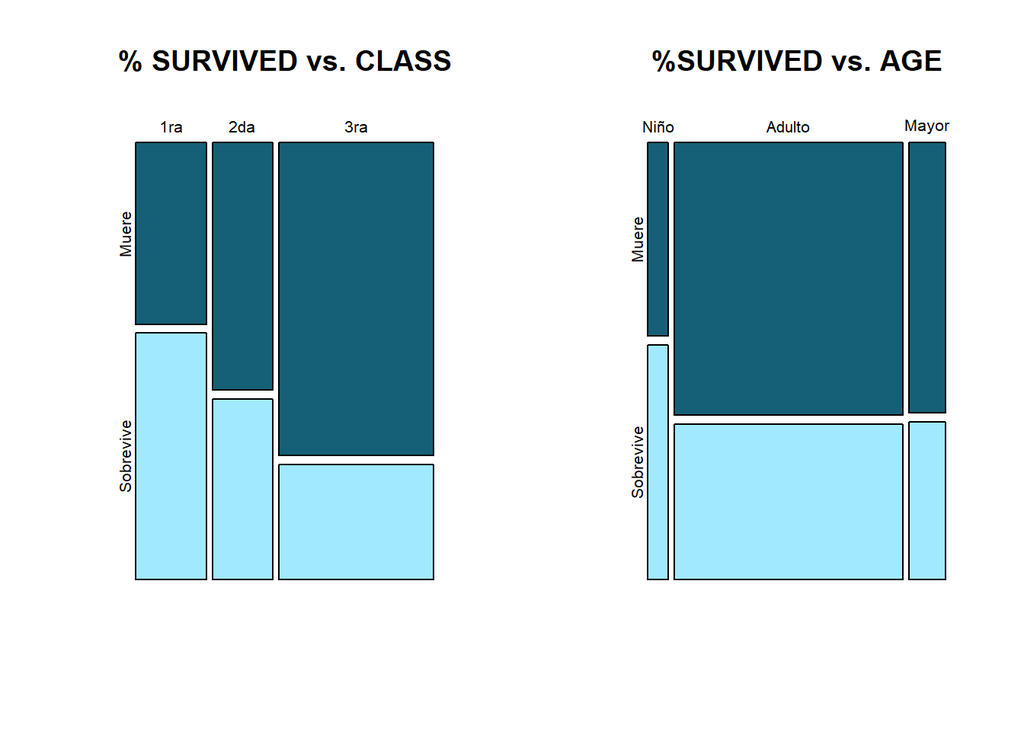

```r
par(mfrow=c(1,2))
plot(tabla_SCT, col = c("#156077","#A1E9FF"), main = "% SURVIVED vs. CLASS")
plot(tabla_SAT, col = c("#156077","#A1E9FF"), main = "%SURVIVED vs. AGE")
```

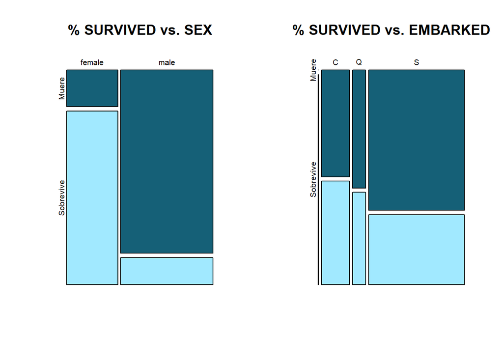

```r
plot(tabla_SST, col = c("#156077","#A1E9FF"), main = "% SURVIVED vs. SEX")
plot(tabla_SET, col = c("#156077","#A1E9FF"), main = "% SURVIVED vs. EMBARKED")
```

## 4.2 Aplicación de pruebas estadísticas para comparar los grupos de datos.

En función de los datos y el objetivo de estudio, aplicar pruebas de contraste de hipótesis, correlaciones, regresiones, etc. Aplicar al menos tres métodos de análisis diferentes.  
R/: Se realiza: correlación, cálculo intervalo de confianza, Knn,tabla de contingencia, modelo predictivo de decisión.

```r
#VA <- c("Pclass", "Embarked","Sex","Tipo_Persona","Survived")
VA <- c("Pclass","Sex","Tipo_Persona","Survived")
df1 <- c()
df1 <- df[,VA]

set.seed(1)
data_random <- df1[sample(nrow(df1)),]
###empieza modelo##
set.seed(666)
y <- data_random[,4]
X <- data_random[,1:3]
summary(y)
```

```
##     Muere Sobrevive
##       815       494
```

```r
summary(X)
```

```
##  Pclass        Sex            Tipo_Persona
##  1ra:323   Length:1309        Niño  :  93
##  2da:277   Class :character   Adulto:1048
##  3ra:709   Mode  :character   Mayor : 168
```

**Nueva data test y train**:  
Elegimos el subconjunto de entrenamiento y de prueba calculando cuántas filas corresponde dos tercios de los datos (2*1309/3=872) y dividimos el conjunto:

```r
trainX <- X[1:872,]
trainy <- y[1:872]
testX <- X[873:1309,]
testy <- y[873:1309]

dim(trainX)
```

```
## [1] 872   3
```

```r
dim(trainy)
```

```r
dim(testX)
```

```
## [1] 437   3
```

```r
dim(testy)
```

```r
#indexes = sample(1:nrow(df1), size=floor((2/3)*nrow(df1)))
#trainX<-X[indexes,]
#trainy<-y[indexes]
#testX<-X[-indexes,]
#testy<-y[-indexes]
```

**Creación del modelo, calidad del modelo y extracción de reglas**

```r
summary(trainy)
```

```
##     Muere Sobrevive
##       544       328
```

```r
trainy = as.factor(trainy)
model <- C50::C5.0(trainX, trainy,rules=TRUE )
summary(model)
```

```
##
## Call:
## C5.0.default(x = trainX, y = trainy, rules = TRUE)
##
##
## C5.0 [Release 2.07 GPL Edition]      Mon Jan 03 22:54:44 2022
## -------------------------------
##
## Class specified by attribute `outcome'
##
## Read 872 cases (4 attributes) from undefined.data
##
## Rules:
##
## Rule 1: (560/75, lift 1.4)
##  Sex = male
##  ->  class Muere  [0.865]
##
## Rule 2: (312/59, lift 2.2)
##  Sex = female
##  ->  class Sobrevive  [0.809]
##
## Default class: Muere
##
##
## Evaluation on training data (872 cases):
##
##          Rules
##    ----------------
##      No      Errors
##
##       2  134(15.4%)   <<
##
##
##     (a)   (b)    <-classified as
##    ----  ----
##     485    59    (a): class Muere
##      75   253    (b): class Sobrevive
##
##
##  Attribute usage:
##
##  100.00% Sex
##
##
## Time: 0.0 secs
```

A partir del árbol de decisión de dos hojas que hemos modelado, se pueden extraer las siguientes reglas de decisión (gracias a rules=TRUE podemos imprimir las reglas directamente):

SEX = “Hombre”(male) → Muere. Validez: 86.5%  
SEX = “Mujer”(female) → Sobrevive. Validez: 80.9%

# 5 **Representación de los resultados a partir de gráficas y tablas**

[figure not shown]

```r
model <- C50::C5.0(trainX, trainy)
plot(model)
```

******

Validación del modelo con los datos reservados Una vez tenemos el modelo, podemos comprobar su calidad prediciendo la clase para los datos de prueba que nos hemos reservado al principio.

```r
predicted_model <- predict( model, testX, type="class" )
print(sprintf("La precisión del árbol es: %.4f %%",100*sum(predicted_model == testy) / length(predicted_model)))
```

```
## [1] "La precisión del árbol es: 87.1854 %"
```

Cuando hay pocas clases, la calidad de la predicción se puede analizar mediante una matriz de confusión que identifica los tipos de errores cometidos.

```r
#####SALIA#####
mat_conf<-table(testy,Predicted=predicted_model)
mat_conf
```

```
##            Predicted
## testy       Muere Sobrevive
##   Muere       249        22
##   Sobrevive    34       132
```

Además, tenemos a nuestra disposición el paquete gmodels para obtener información más completa:

```r
if(!require(gmodels)){
    install.packages('gmodels', repos='http://cran.us.r-project.org')
    library(gmodels)
}
CrossTable(testy, predicted_model,prop.chisq  = FALSE, prop.c = FALSE, prop.r =FALSE,dnn = c('Reality', 'Prediction'))
```

```
##
##
##    Cell Contents
## |-------------------------|
## |                       N |
## |         N / Table Total |
## |-------------------------|
##
##
## Total Observations in Table:  437
##
##
##              | Prediction
##      Reality |     Muere | Sobrevive | Row Total |
## -------------|-----------|-----------|-----------|
##        Muere |       249 |        22 |       271 |
##              |     0.570 |     0.050 |           |
## -------------|-----------|-----------|-----------|
##    Sobrevive |        34 |       132 |       166 |
##              |     0.078 |     0.302 |           |
## -------------|-----------|-----------|-----------|
## Column Total |       283 |       154 |       437 |
## -------------|-----------|-----------|-----------|
##
##
```

# 6 **Resolución del problema**

A partir de los resultados obtenidos, ¿cuales son las conclusiones? Los resultados permiten responder el problema? R:/ Adicional a las conclusiones a lo largo de la realización de la PEC podemos concluir que:

Los hombres tienen un 86.5% de posibilidad de morir.  
Las mujeres tienen más posibilidades de sobrevivir (80.9%)

Por tanto podemos concluir que “las mujeres primero que los hombres”.

Las distintas embarcaciones C,Q y S mostraron un rango entre el 50% y 66% en mortalidad.

La 3ra clase es la que murió más 73% y la 1ra la que menos (42%). Conclusión: la posición social tiene privilegios.

# 7 **Código**

- Adjuntar el código, preferiblemente en R.

En esta sesión se exportan los datos preparados para el entrenamiento del modelo.

```r
write.csv(df1,"D:\\UOC\\9. Tipología y Ciclo de vida de los datos\\PRA2\\Entrega\\DatosFinales.csv", row.names = FALSE)
```

**Link con código en repositorio GIT**  
https://github.com/diegoquintero424/PRA2_Limpieza-y-analisis-de-datos

**Link del video en google drive**  
https://drive.google.com/file/d/1c8itVL0yoo23qeZ7QAZPz7JXkBREjthj/view?ts=61d3c3b8

# 8 **Contribución de participantes**

| Contribuciones | Firma |
| --- | --- |
| 1. Descripción del dataset | DQ, AP |
| 2. Integración y selección de los datos | DQ, AP |
| 3. Limpieza de los datos. | DQ, AP |
| 4. Análisis de los datos. | DQ, AP |
| 5. Representación de los resultados | DQ, AP |
| 6. Resolución del problema | DQ, AP |
| 7. Código | DQ, AP |
| 8. video y presentación | DQ, AP |

**Iniciales:**  
**AP:** Adrian Felipe Pinzon Hurtado  
**DQ:** Diego Armando Quintero Quiñones

# 9 **Fuentes**

https://www.cienciadedatos.net/documentos/9_homogeneidad_de_varianza_homocedasticidad.html#:~:text=El%20supuesto%20de%20homogeneidad%20de,es%20decir%2C%20entre%20diferentes%20grupos.  
Luis Carlos Molina Félix, Ramon Sangüesa i Solé, “Evaluación de modelos”, PID_00165734, Minería de Datos, Biblioteca UOC